# Further Analysis

Yi Lin Liu

April 4, 2017

## Summary of Further Steps:

- Temperature Data for several days have been collected under `temperature- Copy.csv`. To analyze further, several different graphs will be made.
- The same time vs temperature series graph, except this time, the first 24 hour, 12 first and 6 hour predictions will be plotted separately.
  - It is predicted that the error bars (prediction errors) will be smaller for the 1-6h predictions compared to the 1-12 hour predictions and also the 1-24h predictions. This is because the closer the prediction to the actual time, the closer the predicted temperature should be to the actual temperature.
- A plot of the differences between the predicted temperatures(error bars) and the current temperature will be plotted.
- A histogram of when does the worst prediction occur latest, as in the worst forecast that is nearest in time to the actual measured temperature.

## Organizing Raw Data

- This section is more or less a replica of the steps taken to lag the columns and take only the completed rows from the *Weather_mini_project*.

```r
    rm(list = ls())

    raw_File = "temperature - Copy.csv"
    raw_Data = read.table(file=raw_File,header=TRUE,
                          sep=",",stringsAsFactors = FALSE)

    length=dim(raw_Data)[1]
    raw_Data = raw_Data[seq(from=1,to=length,by=2),]



    ## Lagging each column, starting from 3rd column
    ## made into a quick function.
    LagData = function(data,start_Col=3, lag=1, lag_Increment=1){

        for( i in start_Col: length(names(data))){
            data[,start_Col] = data.table::shift(
                x= data[,start_Col], n=lag
            )
            start_Col = start_Col+1
            lag =lag+lag_Increment
        }

        return(data)
    }

    lagged = LagData(data=raw_Data, lag_Increment = 1)


    ##  Selecting only the complete data
    library(dplyr)
    data = lagged %>%
        filter(!is.na(forcast.temperature.in.24h..C.))

    ##  Changing the column names:
    col_Names = c("Date","current")
    for(i in 3:length(names(data))){
        col_Names = append(col_Names, paste("For",i-2,"h",sep=""))
    }

    colnames(data) <- col_Names
```

## Plotting Time vs Temp Series:

1: Clearing Memory:

```r
    rm(list = setdiff(ls(),"data"))
```

2: Getting All Data:

- End goal is to calculate all the required data.
  - max, min predicated values
  - error bar values
  - hour indicating worst predication closest to actual temperature in time.

```r
    ##  include: the list of cols(names/index) to include for
    ##  data frame
    ##  Returns new data frame containing
    ##  date, current temp,perdications wanted,max and min error bars
    Organize = function(data, include){

        new_Data =data[include]
        ##  Max and Min predictions
        max = apply(new_Data,1,function(x){ max(x)} )
        min = apply(new_Data,1,function(x){ min(x)} )


        ##  Processing the index(hour) of maximum difference
        max_Location = vector()
        for(i in 1: length(max)){

            row = new_Data[i,]
            ##  Which number to look for
            if(abs(max[i] - data$current[i])>
               abs(min[i] - data$current[i]))
                locate = max[i]
            else
                locate = min[i]

            ##  Finding index
            if(max[i]==data$current[i] &
               min[i]==data$current[i])
                max_Location[i]=0
            else
                max_Location[i]= match(locate, row)


        }

        ##  attaching to a data frame.

        new_Data = cbind(date = data$Date,
                         current = data$current,
                        new_Data,
                        maxPredict=max,
                        minPredict=min,
                        max_Diff = max_Location)

        ##Adding the erMax and erMin from current Temp

        new_Data = new_Data %>%
            mutate(erMax=maxPredict-current)%>%
            mutate(erMin=minPredict-current)
        return(new_Data)
    }
```

```r
    names = colnames(data)

    include24h = grep("For1h",names):
        grep("For24h",names)
    data24h = Organize(data,include24h )

    include12h = grep("For1h",names):
        grep("For12h",names)
    data12h = Organize(data, include12h)


    include6h = grep("For1h",names):
        grep("For6h",names)
    data6h = Organize(data, include6h)
```

3: Plotting the Time vs Temp Series:

```r
    plotTimeTempSeries = function(data, title){
        library(ggplot2)
        plot = ggplot(data=data, aes(x=strptime(data$date,format="%m/%d/%Y %H:%M"),
                y=data$current) ) + geom_point(color="red",size=2.5)+
            scale_x_datetime() +
            ##  titles and things
            xlab("Time")+ylab("Temp in C")+
            ggtitle(title)+
            ##  Error Bar
            geom_errorbar(aes(ymin=data$current,
                              ymax = data$maxPredict),
                          color = "blue")+
                geom_errorbar(aes(ymin=data$minPredict,
                              ymax = data$current),
                              color="blue")


    }
```

- [Formatting Notes](https://github.com/tidyverse/ggplot2/wiki/Mixing-ggplot2-graphs-with-other-graphical-output)

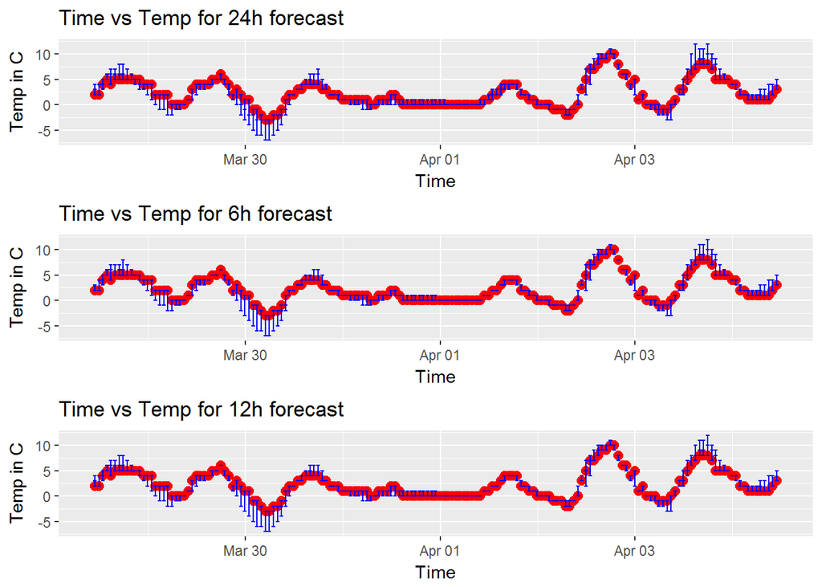

```r
    library(ggplot2)
    library(gridExtra)
    p24h = plotTimeTempSeries(data24h,"Time vs Temp for 24h forecast")
    p12h = plotTimeTempSeries(data12h,"Time vs Temp for 12h forecast")
    p6h = plotTimeTempSeries(data6h,"Time vs Temp for 6h forecast")


    grid.arrange(p24h,p6h,p12h)
```

```r
    ##  Save the graphs for better viewing
    ggsave("./Pictures/p24h.png", p24h, device="png")
    ggsave("./Pictures/p12h.png", p12h, device="png")
    ggsave("./Pictures/p6h.png", p6h, device="png")
```

## Plotting Difference Graph Between Error Bars:

1: Make a function that plots the graph of error bars

```r
     plotEr = function(data, title){
        library(ggplot2)
        library(tidyr)
        library(dplyr)

        ## joining the erUp and erDown
        plot_Data = select(data, c(date,erMax,erMin))
        plot_Data = gather(plot_Data, key="Type",
                           value = "value",erMax,erMin)

        plot = ggplot(data=plot_Data, aes(x=strptime(plot_Data$date,format="%m/%d/%Y %H:%M"),
                y=value, color=Type) ) + geom_line()+
            scale_x_datetime() +
            ##  titles and things
            xlab("Time")+ylab("Magnitude of Error")+
            ggtitle(title)+facet_wrap(~Type)

        return(plot)
     }
```

2: Plotting the Error:

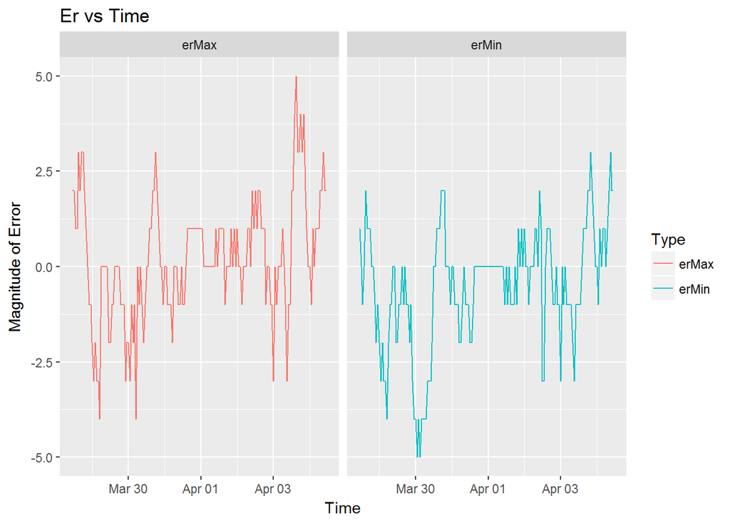

```r
    p24hEr = plotEr(data24h,"Er vs Time")
    p24hEr
```

```r
    ggsave(file="./Pictures/p24hEr.png",p24hEr,device="png")
```

## Worst Perdication Time:

- The idea is to locate the least accurate predication

```r
     plotWorstAsTime = function(data, title){
        library(ggplot2)

        plot = ggplot(data=data, aes(x=strptime(data$date,format="%m/%d/%Y %H:%M"),
                y=max_Diff) ) + geom_point()+
            scale_x_datetime() +
            ##  titles and things
            xlab("Time")+ylab("Earliest Worst forecast Hour")+
            ggtitle(title)

        return(plot)
     }
```

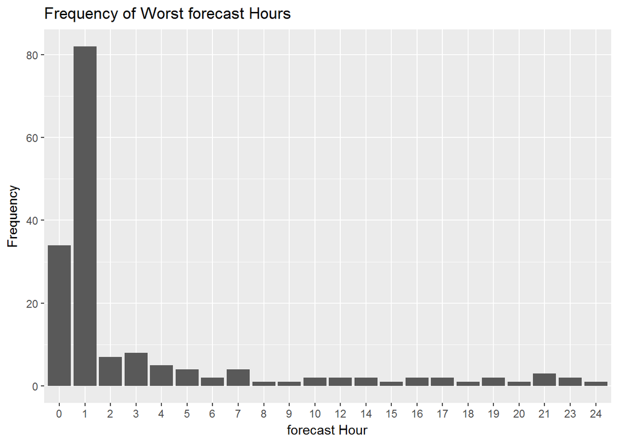

```r
    forWT = plotWorstAsTime(data24h,"Earliest Worst Prediction")

    ##  Histograms
    forWTH = ggplot(data = as.data.frame(
        table(data24h$max_Diff)),
        aes(x=Var1,y=Freq))+
        geom_bar(stat="identity")+
        xlab("forecast Hour")+ ylab("Frequency")+
        ggtitle("Frequency of Worst forecast Hours")

    ggsave("./Pictures/ClosestWorstPredication.png", forWTH, device="png")
    write.table(data24h,file="24hForecast.csv",sep=",",
                col.names = TRUE, row.names=FALSE)

    forWTH
```